# Cardiovascular Disease Prediction: Data Analysis and Machine Learning Model Development.

#### These findings underscore the importance of considering gender and cardiovascular conditions in medical research and treatment strategies.

#### N.)Height vs Weight by Cholesterol Level.

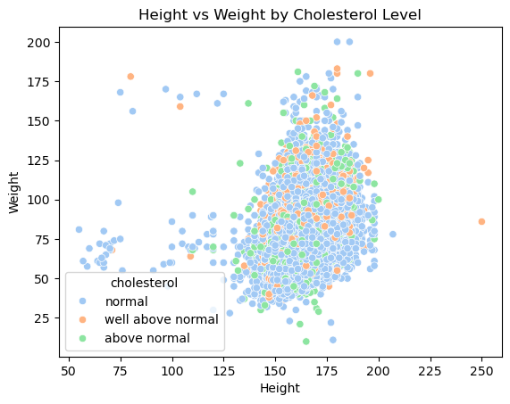

```python
sns.scatterplot(x='height', y='weight', hue='cholesterol', data=df, palette="pastel")
plt.title('Height vs Weight by Cholesterol Level')
plt.xlabel('Height')
plt.ylabel('Weight')
plt.show()
```

#### Scatter plot of height vs weight, colored by cholesterol level:

- Central cluster of normal values
- Outliers with elevated cholesterol
- Pastel colors differentiate cholesterol levels.

#### O.)Pairplot of Health Attributes by Cardiovascular Disease.

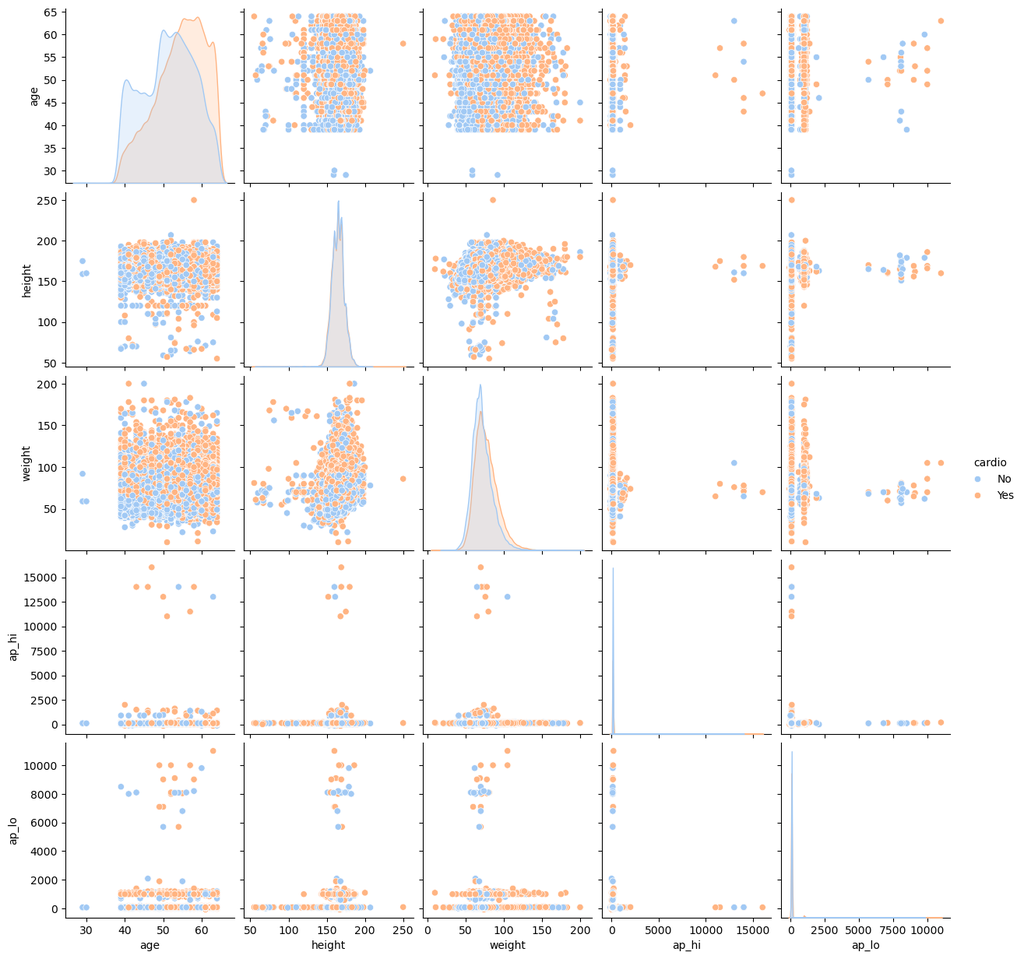

```python
sns.pairplot(df[['age', 'height', 'weight', 'ap_hi', 'ap_lo', 'cholesterol', 'gluc', 'cardio']], hue='cardio', palette="pastel")
plt.show()
```

- Physical attributes
- Health metrics
- Cardiovascular disease presence

#### Reveals interactions and distributions to predict cardio.

#### P.)Frequency graph of dataset.

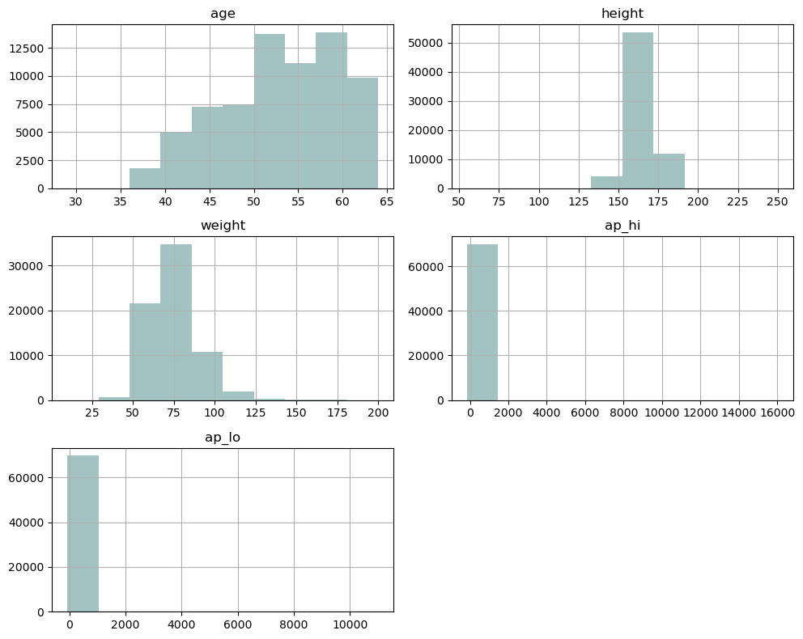

```python
freqgraph = df.select_dtypes(include=['float64', 'int64'])
freqgraph.hist(figsize=(10, 8), color=['#a3c2c2'])
plt.tight_layout()
plt.show()
```

#### The histograms reveal the distribution of key features in the dataset:

- Age: Concentrated between 40-60, peaking in the mid-50s
- Height: Centered around 165-175 cm
- Weight: Peaking at 70-80 kg
- Blood Pressure:
  - Systolic (ap_hi): Mostly under 200, but with extreme outliers
  - Diastolic (ap_lo): Clustered below 100, with significant outliers

#### The dataset appears consistent for age, height, and weight, but blood pressure features require further investigation due to notable outliers, potentially indicating errors or extreme cases.

## Multivariate Analysis

### 1.)Correlation Heatmap.

```python
numeric_df = df.select_dtypes(include='number')
correlation_matrix = numeric_df.corr()
print(correlation_matrix)
```

```
             age    height    weight     ap_hi     ap_lo
age     1.000000 -0.081506  0.053561  0.020854  0.017620
height -0.081506  1.000000  0.290968  0.005488  0.006150
weight  0.053561  0.290968  1.000000  0.030702  0.043710
ap_hi   0.020854  0.005488  0.030702  1.000000  0.016086
ap_lo   0.017620  0.006150  0.043710  0.016086  1.000000
```

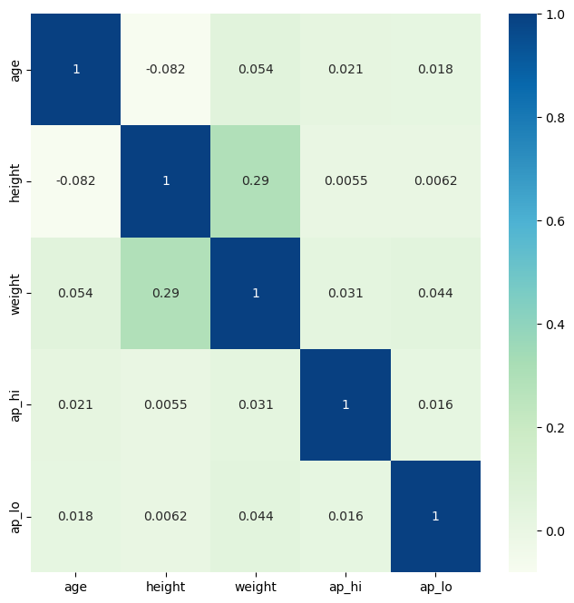

```python
plt.figure(figsize=(8,8))
sns.heatmap(correlation_matrix,annot=True,cmap='GnBu')
plt.show()
```

#### These findings provide a detailed understanding of the relationships between features, informing cardiovascular risk assessment and health strategies.

## Data Cleaning

### Missing values.

```python
print(len(df[df.duplicated()]))
```

```
3208
```

```python
#Checking for null values
df.isna().sum()
```

```
age            0
gender         0
height         0
weight         0
ap_hi          0
ap_lo          0
cholesterol    0
gluc           0
smoke          0
alco           0
active         0
cardio         0
dtype: int64
```

```python
pip install missingno
```

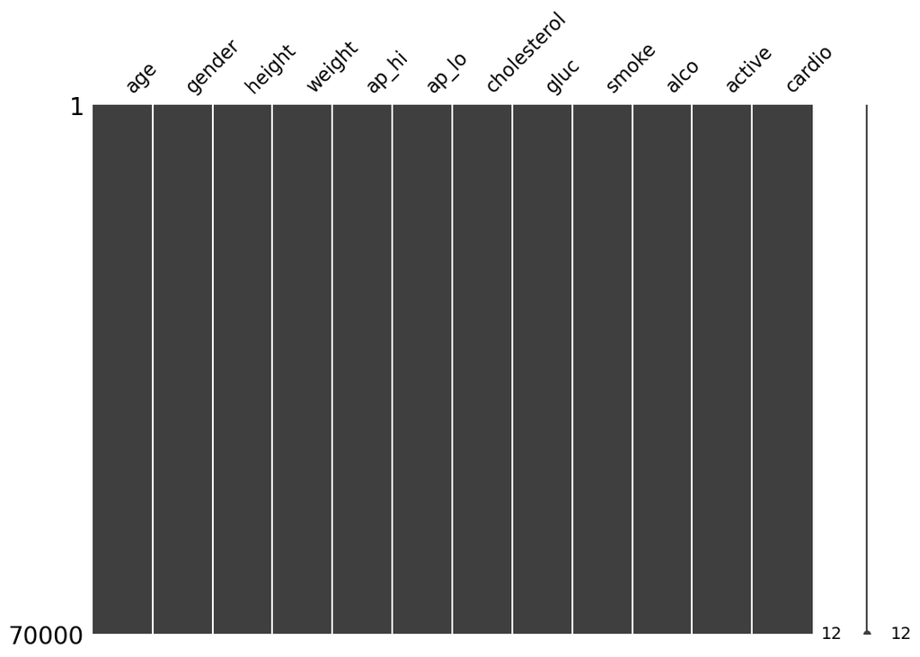

```python
import missingno as msno

# Visualize missing data
msno.matrix(df, figsize=(12, 8))
```

#### The `missingno.matrix` plot reveals no missing data in the dataset. Here's what the plot indicates:

- Black bars represent present data
- No white spaces, meaning no missing values

#### In summary, the dataset has complete entries for each row, with no missing data in the displayed columns.

## Preprocessing and Train-Test Split for Cardiovascular Data.

```python
import pandas as pd
import seaborn as sns
import matplotlib.pyplot as plt
import numpy as np
df=pd.read_csv('Desktop/cardio_train.csv')
df
```

|  | id | age | gender | height | weight | ap_hi | ap_lo | cholesterol | gluc | smoke | alco | active | cardio |
| --- | --- | --- | --- | --- | --- | --- | --- | --- | --- | --- | --- | --- | --- |
| 0 | 0 | 18393 | 2 | 168 | 62.0 | 110 | 80 | 1 | 1 | 0 | 0 | 1 | 0 |
| 1 | 1 | 20228 | 1 | 156 | 85.0 | 140 | 90 | 3 | 1 | 0 | 0 | 1 | 1 |
| 2 | 2 | 18857 | 1 | 165 | 64.0 | 130 | 70 | 3 | 1 | 0 | 0 | 0 | 1 |
| 3 | 3 | 17623 | 2 | 169 | 82.0 | 150 | 100 | 1 | 1 | 0 | 0 | 1 | 1 |
| 4 | 4 | 17474 | 1 | 156 | 56.0 | 100 | 60 | 1 | 1 | 0 | 0 | 0 | 0 |
| ... | ... | ... | ... | ... | ... | ... | ... | ... | ... | ... | ... | ... | ... |
| 69995 | 99993 | 19240 | 2 | 168 | 76.0 | 120 | 80 | 1 | 1 | 1 | 0 | 1 | 0 |
| 69996 | 99995 | 22601 | 1 | 158 | 126.0 | 140 | 90 | 2 | 2 | 0 | 0 | 1 | 1 |
| 69997 | 99996 | 19066 | 2 | 183 | 105.0 | 180 | 90 | 3 | 1 | 0 | 1 | 0 | 1 |
| 69998 | 99998 | 22431 | 1 | 163 | 72.0 | 135 | 80 | 1 | 2 | 0 | 0 | 0 | 1 |
| 69999 | 99999 | 20540 | 1 | 170 | 72.0 | 120 | 80 | 2 | 1 | 0 | 0 | 1 | 0 |

70000 rows × 13 columns

```python
from sklearn.preprocessing import StandardScaler
from sklearn.model_selection import train_test_split
```

```python
print(df.columns)
```

```
Index(['id', 'age', 'gender', 'height', 'weight', 'ap_hi', 'ap_lo',
       'cholesterol', 'gluc', 'smoke', 'alco', 'active', 'cardio'],
      dtype='object')
```

```python
df_processed = df.drop(columns=['id'], errors='ignore')
```

```python
scaler = StandardScaler()
columns_to_scale = ['age', 'height', 'weight', 'ap_hi', 'ap_lo']
df_processed[columns_to_scale] = scaler.fit_transform(df_processed[columns_to_scale])
```

```python
X = df_processed.drop(columns=['cardio'])
y = df_processed['cardio']
```

```python
X_train, X_test, y_train, y_test = train_test_split(X, y, test_size=0.2, random_state=42)
X_train
```

|  | age | gender | height | weight | ap_hi | ap_lo | cholesterol | gluc | smoke | alco | active |
| --- | --- | --- | --- | --- | --- | --- | --- | --- | --- | --- | --- |
| 47339 | 0.975641 | 1 | -1.261771 | 0.402504 | 0.007679 | -0.035180 | 2 | 1 | 0 | 0 | 1 |
| 67456 | -1.115365 | 2 | -0.287358 | -0.292150 | 0.072610 | -0.035180 | 1 | 1 | 0 | 0 | 0 |
| 12308 | 0.672467 | 2 | 1.174262 | 1.236089 | 0.137541 | 0.017879 | 1 | 1 | 0 | 0 | 1 |
| 32557 | 1.579556 | 2 | 1.052460 | 0.124642 | -0.057251 | -0.077627 | 1 | 1 | 0 | 0 | 1 |
| 664 | 0.329168 | 1 | -0.530961 | -0.986804 | -0.057251 | -0.088238 | 1 | 1 | 0 | 0 | 1 |
| ... | ... | ... | ... | ... | ... | ... | ... | ... | ... | ... | ... |
| 37194 | -1.405568 | 2 | 0.687055 | 0.055177 | 0.137541 | -0.088238 | 1 | 1 | 1 | 0 | 1 |
| 6265 | 1.515922 | 2 | -0.287358 | -0.083754 | 0.202472 | -0.035180 | 1 | 1 | 0 | 0 | 1 |
| 54886 | 1.669941 | 1 | 0.565254 | -0.014288 | -0.057251 | -0.088238 | 1 | 1 | 0 | 0 | 1 |
| 860 | -0.503343 | 1 | 0.321650 | -0.292150 | -0.057251 | -0.088238 | 1 | 1 | 0 | 0 | 0 |
| 15795 | -1.765080 | 2 | 1.539667 | -0.708942 | -0.057251 | -0.088238 | 1 | 1 | 0 | 0 | 1 |

56000 rows × 11 columns

## Simple Model Building.

### Importing Essential Libraries for Machine Learning Models and Metrics.

```python
from sklearn.preprocessing import StandardScaler, PolynomialFeatures
from sklearn.tree import DecisionTreeClassifier
from sklearn.ensemble import RandomForestClassifier
from sklearn.neighbors import KNeighborsClassifier
from sklearn.naive_bayes import GaussianNB
from sklearn.svm import SVC
from sklearn.linear_model import LogisticRegression
from sklearn.linear_model import LinearRegression
from sklearn.metrics import accuracy_score, r2_score
from sklearn.preprocessing import PolynomialFeatures
```

### 1. Logistic Regression.

```python
logistic_model = LogisticRegression(max_iter=1000)
logistic_model.fit(X_train, y_train)
```

```
LogisticRegression(max_iter=1000)
```

```python
logistic_pred = logistic_model.predict(X_test)
logistic_acc = accuracy_score(y_test, logistic_pred)
print(f'Logistic Regression Accuracy: {logistic_acc:.4f}')
```

```
Logistic Regression Accuracy: 0.7233
```

```python
logistic_pred = logistic_model.predict(X_train)
logistic_acc_train = accuracy_score(y_train, logistic_pred)
print(f'Logistic Regression Accuracy: {logistic_acc_train:.4f}')
```

```
Logistic Regression Accuracy: 0.7192
```

### 2.Linear Regression

```python
linear_model = LinearRegression()
linear_model.fit(X_train, y_train)
```

```
LinearRegression()
```

```python
linear_pred = linear_model.predict(X_test)
linear_r2 = r2_score(y_test, linear_pred)
print(f'Linear Regression R² Score: {linear_r2:.4f}')
```

```
Linear Regression R² Score: 0.1278
```

```python
linear_pred = linear_model.predict(X_train)
linear_r2_train = r2_score(y_train, linear_pred)
print(f'Linear Regression R² Score: {linear_r2_train:.4f}')
```

```
Linear Regression R² Score: 0.1182
```

### 3.Decision Tree Classifier.

```python
dtc_model = DecisionTreeClassifier(random_state=42)
dtc_model.fit(X_train, y_train)
```

```
DecisionTreeClassifier(random_state=42)
```

```python
dtc_pred = dtc_model.predict(X_test)
dtc_acc = accuracy_score(y_test, dtc_pred)
print(f'Decision Tree Accuracy: {dtc_acc:.4f}')
```

```
Decision Tree Accuracy: 0.6284
```

```python
dtc_pred = dtc_model.predict(X_train)
dtc_acc_train = accuracy_score(y_train, dtc_pred)
print(f'Decision Tree Accuracy: {dtc_acc_train:.4f}')
```

```
Decision Tree Accuracy: 0.9998
```

### 4.K-Nearest Neighbors Classifier.

```python
knn_model = KNeighborsClassifier()
knn_model.fit(X_train, y_train)
```

```
KNeighborsClassifier()
```

```python
knn_pred = knn_model.predict(X_test)
knn_acc = accuracy_score(y_test, knn_pred)
print(f'KNN Accuracy: {knn_acc:.4f}')
```

```
KNN Accuracy: 0.6484
```

```python
knn_pred = knn_model.predict(X_train)
knn_acc_train = accuracy_score(y_train, knn_pred)
print(f'KNN Accuracy: {knn_acc_train:.4f}')
```

```
KNN Accuracy: 0.7656
```

### 5.Naive Bayes Classifier.

```python
nb_model = GaussianNB()
nb_model.fit(X_train, y_train)
```

```
GaussianNB()
```

```python
nb_pred = nb_model.predict(X_test)
nb_acc = accuracy_score(y_test, nb_pred)
print(f'Naive Bayes Accuracy: {nb_acc:.4f}')
```

```
Naive Bayes Accuracy: 0.5933
```

```python
nb_pred = nb_model.predict(X_train)
nb_acc_train = accuracy_score(y_train, nb_pred)
print(f'Naive Bayes Accuracy: {nb_acc_train:.4f}')
```

```
Naive Bayes Accuracy: 0.5953
```

### 6.Support Vector Machine.

```python
svm_model = SVC()
svm_model.fit(X_train, y_train)
```

```
SVC()
```

```python
svm_pred = svm_model.predict(X_test)
svm_acc = accuracy_score(y_test, svm_pred)
print(f'SVM Accuracy: {svm_acc:.4f}')
```

```
SVM Accuracy: 0.7364
```

```python
svm_pred = svm_model.predict(X_train)
svm_acc_train = accuracy_score(y_train, svm_pred)
print(f'SVM Accuracy: {svm_acc_train:.4f}')
```

```
SVM Accuracy: 0.7341
```

### 7.Random Forest Classifier

```python
rfc_model = RandomForestClassifier(n_estimators=80, random_state=42)
rfc_model.fit(X_train, y_train)
```

```
RandomForestClassifier(n_estimators=80, random_state=42)
```

```python
rfc_pred = rfc_model.predict(X_test)
rfc_acc = accuracy_score(y_test, rfc_pred)
print(f'Random Forest Accuracy: {rfc_acc:.4f}')
```

```
Random Forest Accuracy: 0.7137
```

```python
rfc_pred = rfc_model.predict(X_train)
rfc_acc_train = accuracy_score(y_train, rfc_pred)
print(f'Random Forest Accuracy: {rfc_acc_train:.4f}')
```

```
Random Forest Accuracy: 0.9998
```

### 8.Polynomial Regression (Degree-2)

```python
# Generate polynomial features (degree 2)
poly = PolynomialFeatures(degree=2)
X_poly_train = poly.fit_transform(X_train)
X_poly_test = poly.transform(X_test)
```

```python
# Initialize and train Polynomial Regression
linear_poly_model = LinearRegression()
linear_poly_model.fit(X_poly_train, y_train)
```

```
LinearRegression()
```

```python
poly_pred = linear_poly_model.predict(X_poly_test)
poly_r2 = r2_score(y_test, poly_pred)
print(f'Polynomial Regression R² Score: {poly_r2:.4f}')
```

```
Polynomial Regression R² Score: 0.0731
```

```python
poly_pred = linear_poly_model.predict(X_poly_train)
poly_r2_train = r2_score(y_train, poly_pred)
print(f'Polynomial Regression R² Score: {poly_r2_train:.4f}')
```

```
Polynomial Regression R² Score: 0.1736
```